# Making plots with `ggplot2`: histograms, boxplots, line graphs

Author

Casey Schine adapted from Emily Malcolm-White

```r
# load packages
library(tidyverse)
library(ggthemes) # for additional themes
```

# Housekeeping

- Homeworks continue to be due on Wednesday and Friday
- Next week I will post your midterm assignment and we will begin working with the data

## Line Graph

This dataset was produced from US economic time series data available from https://fred.stlouisfed.org/. Type `? economics` to learn more.

```r
data("economics")

# what is in the data?

# ?economics
```

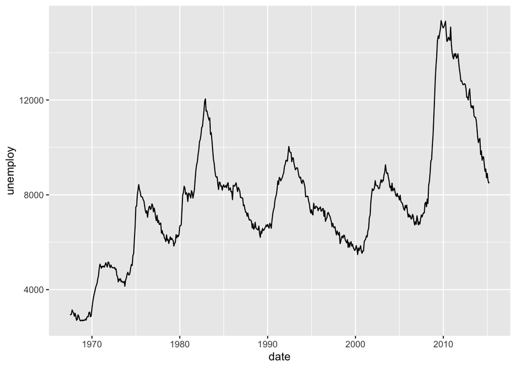

```r
# basic line plot

economics |>
  ggplot(aes(x=date, y=unemploy)) +
  geom_line()
```

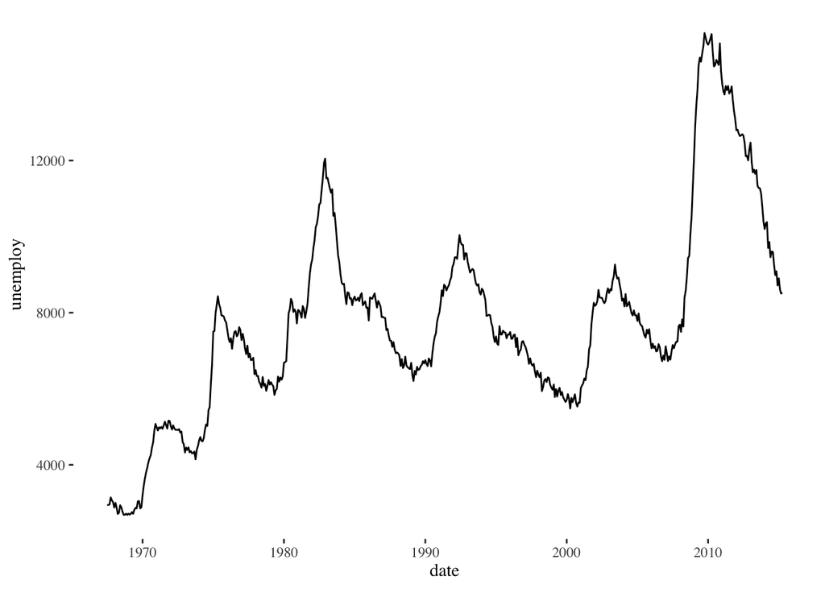

```r
# add theme

economics |>
  ggplot(aes(x=date, y=unemploy)) +
  geom_line() +
  theme_tufte()
```

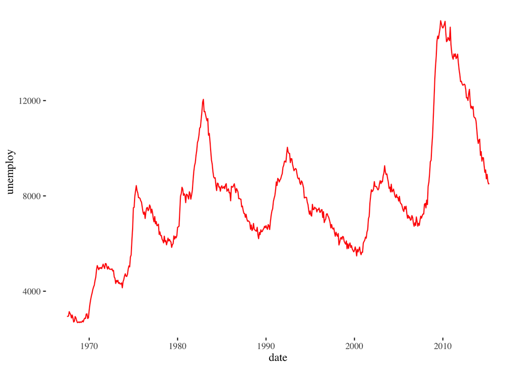

```r
# change color

economics |>
  ggplot(aes(x=date, y=unemploy)) +
  geom_line(color="red") +
  theme_tufte()
```

When is it appropriate to use a line to connect observations like this?

**Tip**

In ggplot2, you use the **`group`** aesthetic in a `geom_line()` plot when you need to explicitly tell R how to group data points together into lines.

**🌶️ Spicy alert**: I am creating a dataset here using some techniques that might be new to you. Don’t worry so much about *how* I created the dataset, you should focus on what the dataset looks like.

```r
# Example dataset
df <- tibble(time = rep(1:5, 2),
             value = c(1, 3, 5, 7, 9, 2, 5, 8, 11, 14),
             category = rep(c("A", "B"), each = 5))

df
```

```
# A tibble: 10 × 3
    time value category
   <int> <dbl> <chr>
 1     1     1 A
 2     2     3 A
 3     3     5 A
 4     4     7 A
 5     5     9 A
 6     1     2 B
 7     2     5 B
 8     3     8 B
 9     4    11 B
10     5    14 B
```

### Without the needed `group` command

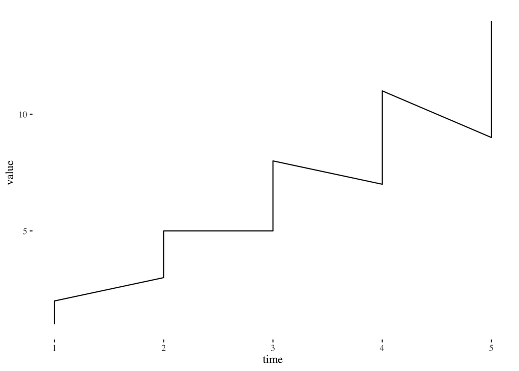

```r
# Incorrect: Only one line drawn without group
# with geom_line

df |>
  ggplot(aes(x=time, y=value)) +
  geom_line() +
  theme_tufte()
```

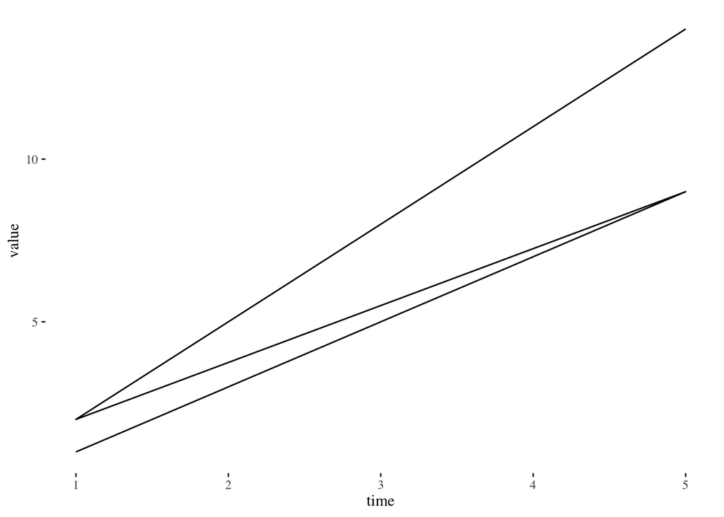

```r
# with geom_path

df |>
  ggplot(aes(x=time, y=value)) +
  geom_path() +
  theme_tufte()
```

### With the `group` command

```r
# Correct: Separate lines for each category using group

# with geom_line
df |>
  ggplot(aes(x=time, y=value, group=category)) +
  geom_line() +
  theme_tufte()
```

[output not shown]

```r
# with geom_path
df |>
  ggplot(aes(x=time, y=value, group=category)) +
  geom_path() +
  theme_tufte()
```

[output not shown]

```r
df |>
  ggplot(aes(x=time, y=value)) +
  geom_path(aes(group=category)) +
  theme_tufte()
```

[output not shown]

### Using `color` (or `linetype`) instead

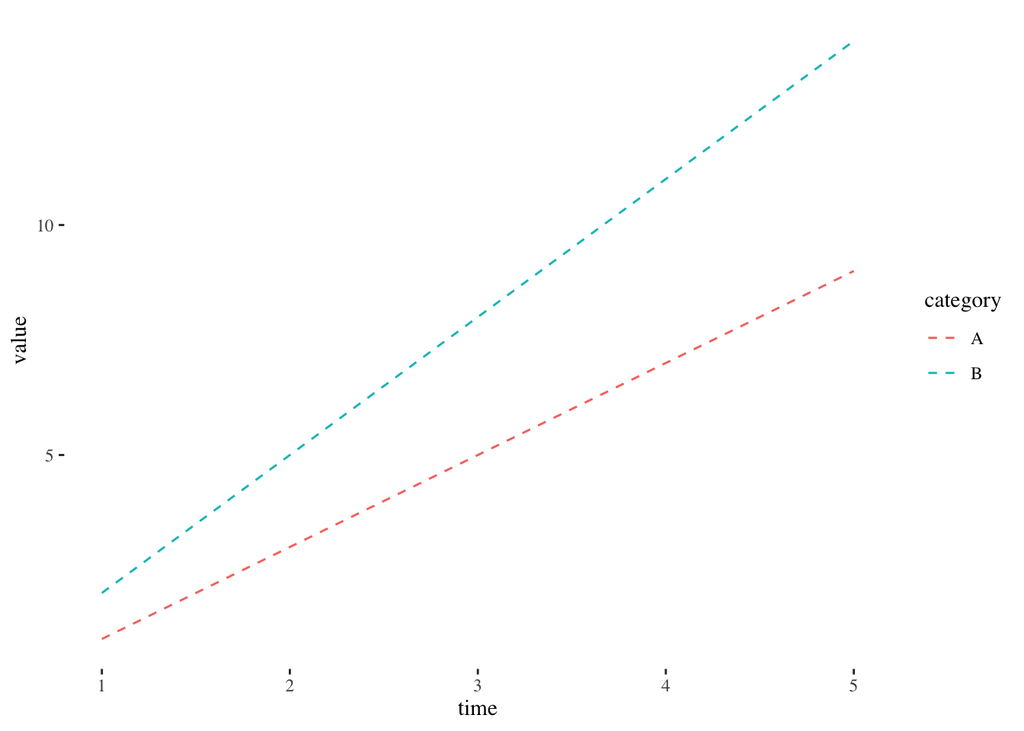

```r
# Automatically groups by color

# change linetype globally
# map category to color

df |>
  ggplot(aes(x=time, y=value, color=category)) +
  geom_line(linetype="dashed") +
  theme_tufte()
```

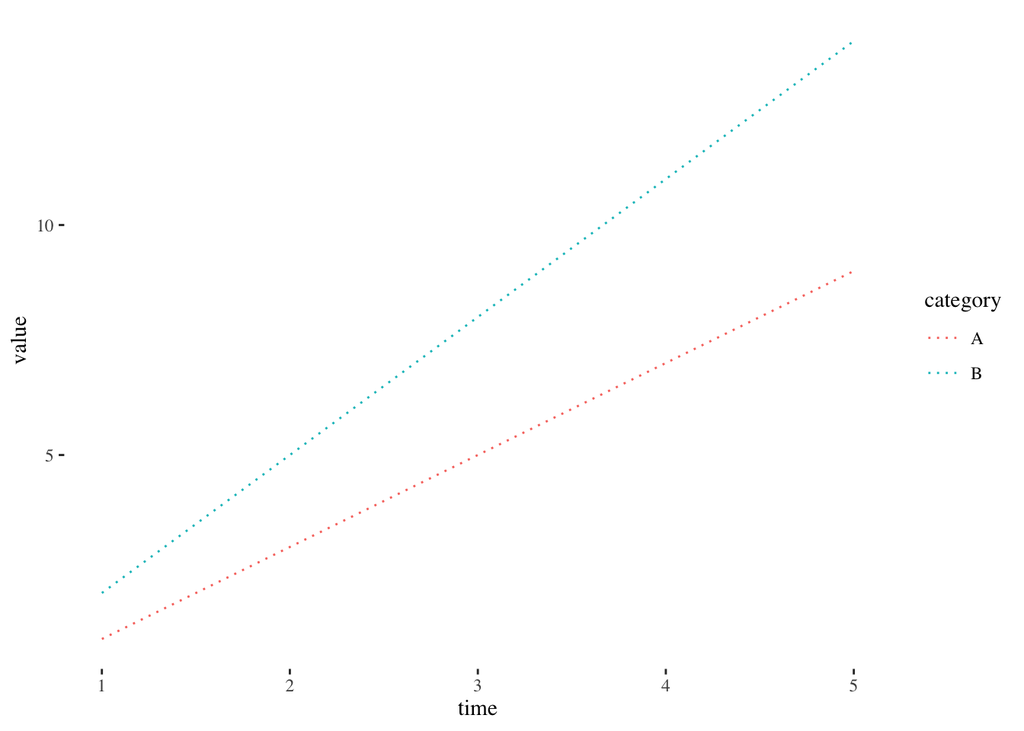

```r
df |>
  ggplot(aes(x=time, y=value, color=category)) +
  geom_line(linetype="dotted") +
  theme_tufte()
```

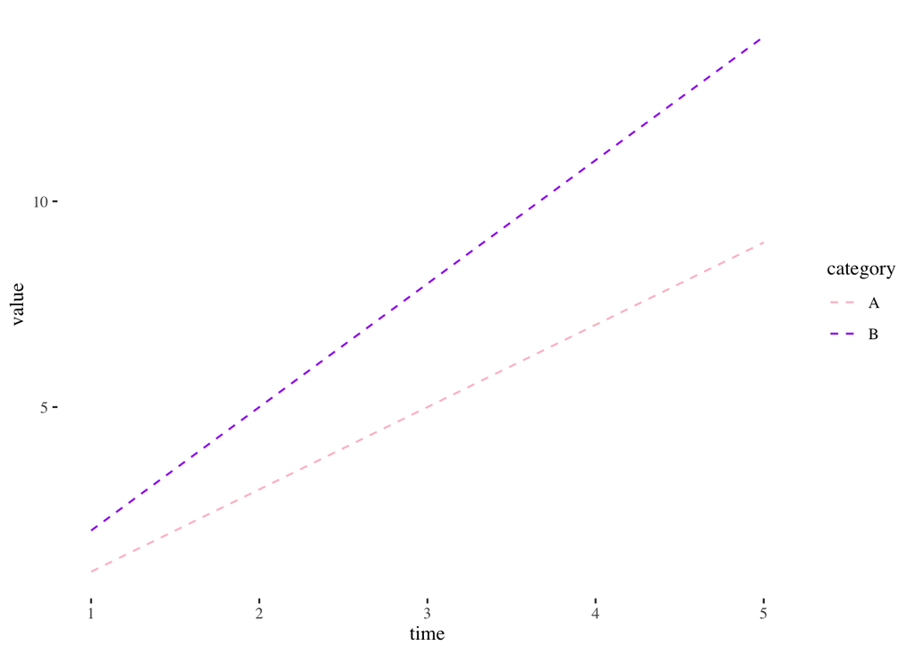

```r
# control colors using scale_color_manual()

df |>
  ggplot(aes(x=time, y=value, color=category)) +
  geom_line(linetype="dashed") +
  scale_color_manual(values=c("pink", "purple")) +
  theme_tufte()
```

### Control linetype when mapped to variable

In class a question came up about how to control linetype when it is mapped to a variable in `aes()` similar to what we do with `scale_color_manual()`. I don’t think anyone will be surprised that the function to do this is called `scale_linetype_manual()`. Below is a coding example of how to use it.

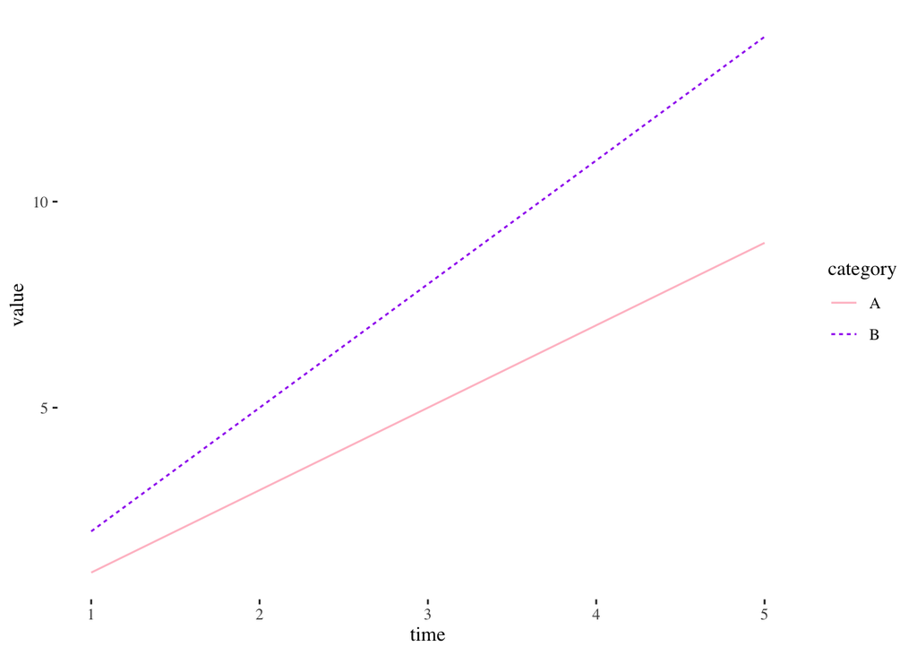

```r
# map linetype to category variable inside aesthetics

df |>
  ggplot(aes(x=time, y=value,
             color=category,
             linetype=category)) +
  geom_line() +
  scale_color_manual(values=c("pink", "purple")) +
  theme_tufte()
```

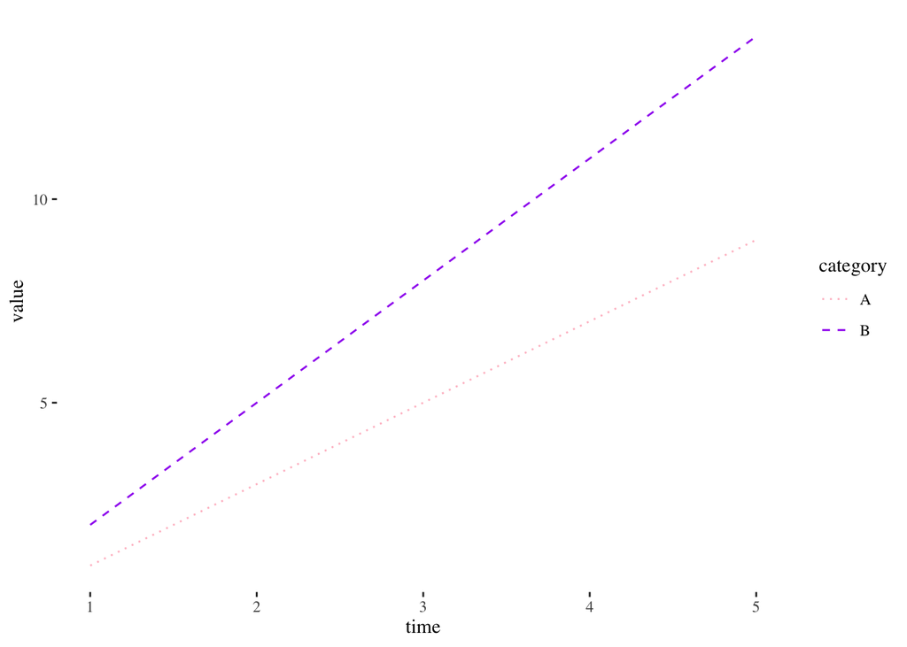

```r
# use scale_linetype_manual() to map to specific linetypes

df |>
  ggplot(aes(x=time, y=value,
             color=category,
             linetype=category)) +
  geom_line() +
  scale_color_manual(values=c("pink", "purple")) +
  scale_linetype_manual(values=c("dotted", "dashed")) +
  theme_tufte()
```

## `possum` data

The possum data frame consists of nine morphometric measurements on each of 104 mountain brushtail possums, trapped at seven Australian sites from Southern Victoria to central Queensland.

There are two different populations (`pop`): `Vic` (Victoria) and `other` (New South Wales or Queensland)

```r
#Be sure to install the DAAG package if you've never used it before...
library(DAAG)
data("possum")

# what is in this dataset??
```

## Histograms using `geom_histogram`

**Tip**

Histograms are great for looking at the distributions of numeric variables

A histogram for the foot length (`footlgth`) of all possums in this dataset:

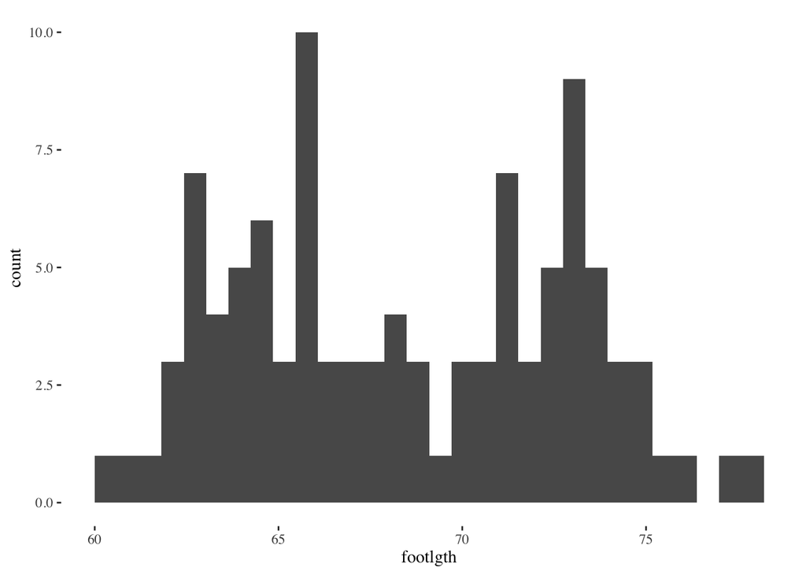

```r
# simple histogram using footlgth

possum |>
  ggplot(aes(x=footlgth)) +
  geom_histogram() +
  theme_tufte()
```

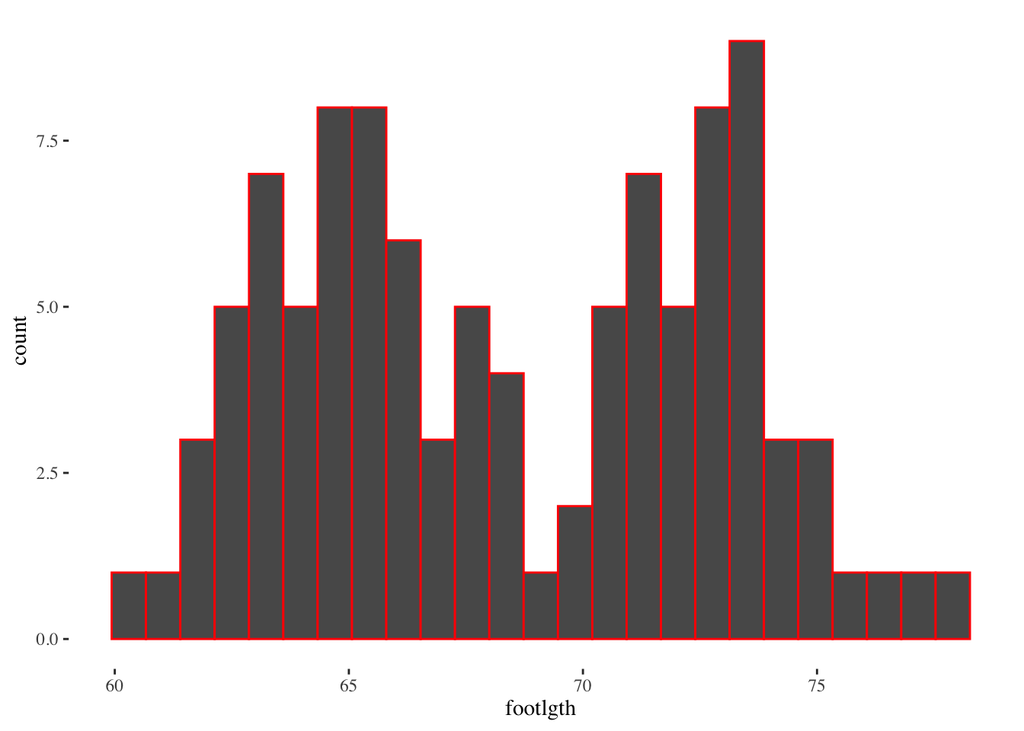

```r
# what do you see?

#change bin size inside geom_histogram() using the bins argument

possum |>
  ggplot(aes(x=footlgth)) +
  geom_histogram(bins=25, color="red") +
  theme_tufte()
```

You can also customize by color:

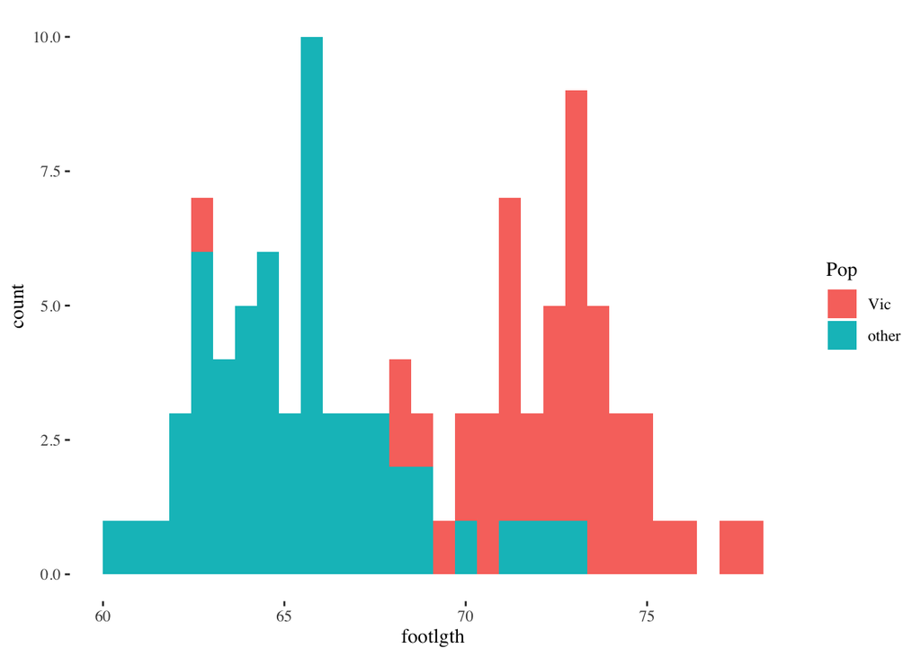

```r
# use color and fill in aes for pop

possum |>
  ggplot(aes(x=footlgth, fill=Pop)) +
  geom_histogram() +
  theme_tufte()
```

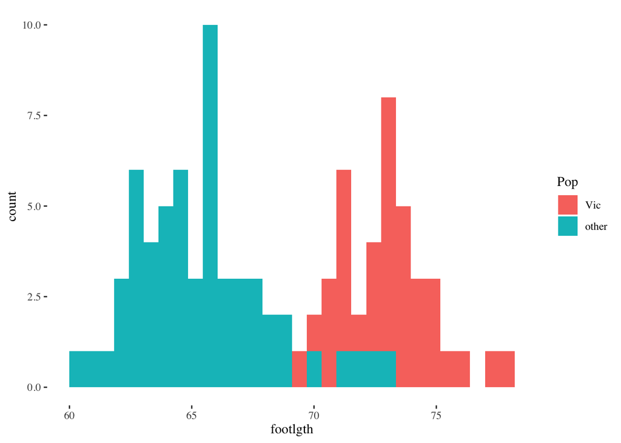

```r
#what do you see?

# use position="identity" inside of geom_histogram to change how it is plotted

possum |>
  ggplot(aes(x=footlgth, fill=Pop)) +
  geom_histogram(position="identity") +
  theme_tufte()
```

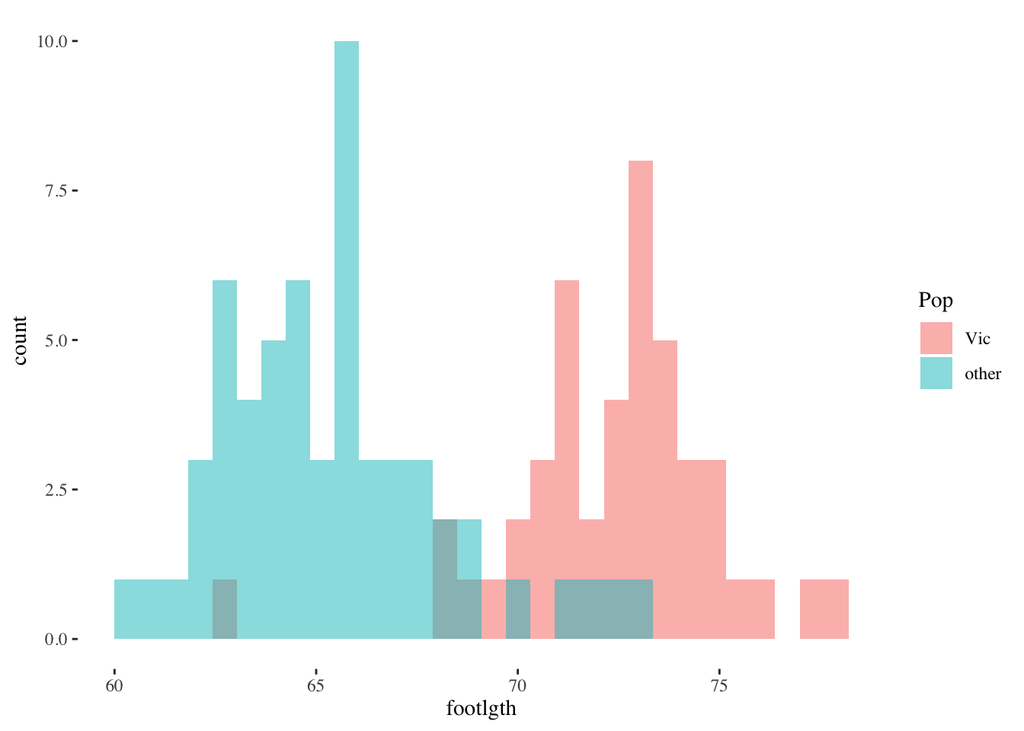

```r
# change transparency using alpha so that you can see both populations

possum |>
  ggplot(aes(x=footlgth, fill=Pop)) +
  geom_histogram(position="identity", alpha=0.5) +
  theme_tufte()
```

Some people prefer to use `geom_density` for a smoother effect:

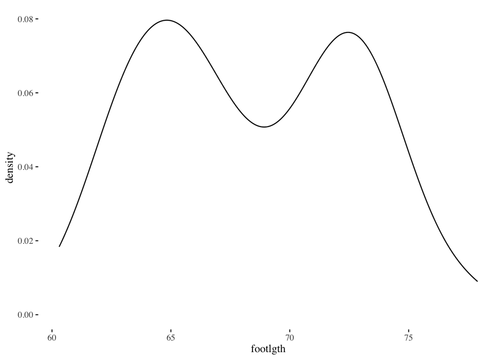

```r
# first use geom_density to look at full dataset

possum |>
  ggplot(aes(x=footlgth)) +
  geom_density() +
  theme_tufte()
```

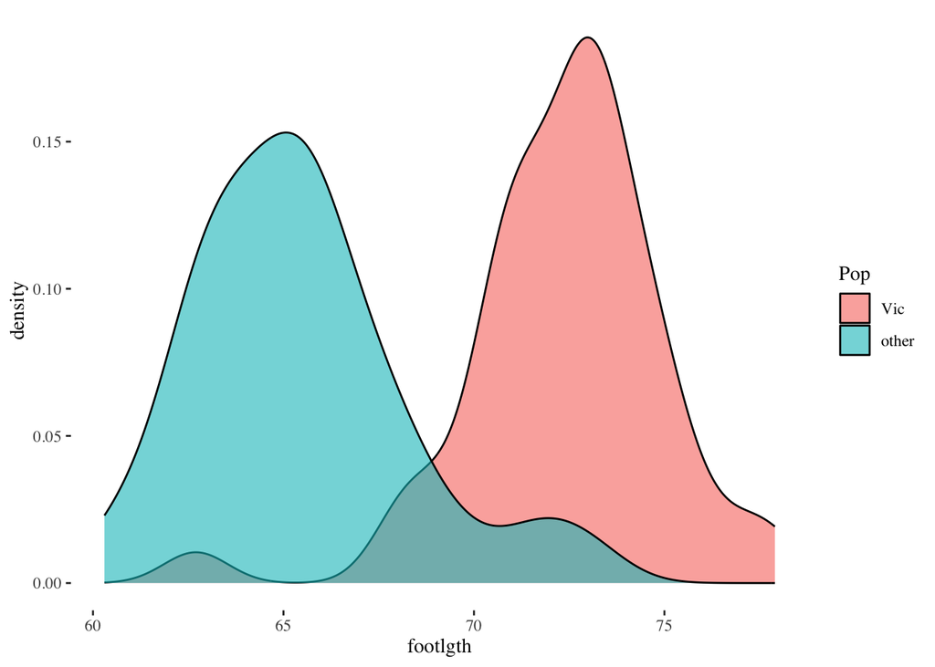

```r
# separate populations (Pop) using fill argument
# use alpha
# add theme

possum |>
  ggplot(aes(x=footlgth, fill=Pop)) +
  geom_density(alpha=0.6) +
  theme_tufte()
```

**Tip**

`geom_density` gives us slightly different information about our data distribution from `geom_histogram`.

With a partner or ins groups of 3 take a look back at the histogram and density plot that we made of the same `footlgth` data, with the separate populations.

What do you see?

What is on x-axis? What is on the y-axis?

What is the difference between the two types of plots? When might you use one versus the other?

We can also control the appearance of our density plots in the same way as the other plot types we have looked at, adding axis labels and controlling colors.

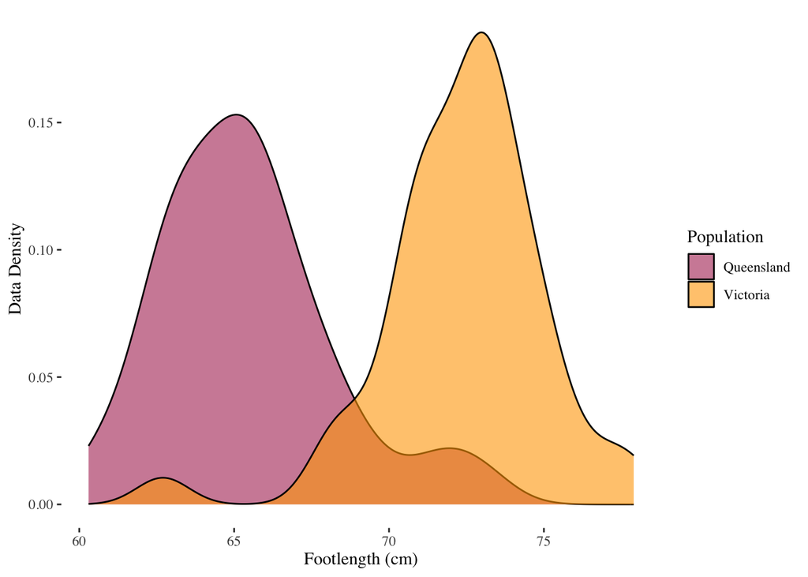

```r
# add axis labels
# add fill label in labs()
# change colors using scale_fill_manual()

possum |>
  mutate(pop_word = case_when(Pop=="Vic" ~ "Victoria",
                              Pop=="other" ~ "Queensland")) |>
  ggplot(aes(x=footlgth, fill=pop_word)) +
  geom_density(alpha=0.6) +
  scale_fill_manual(values=c("maroon", "orange")) +
  labs(x="Footlength (cm)", y="Data Density",
       fill="Population") +
  theme_tufte()
```

We can also alter our dataset before passing it into a plot. Here we have filtered for only male possums, and then plotted the resulting data density distribution.

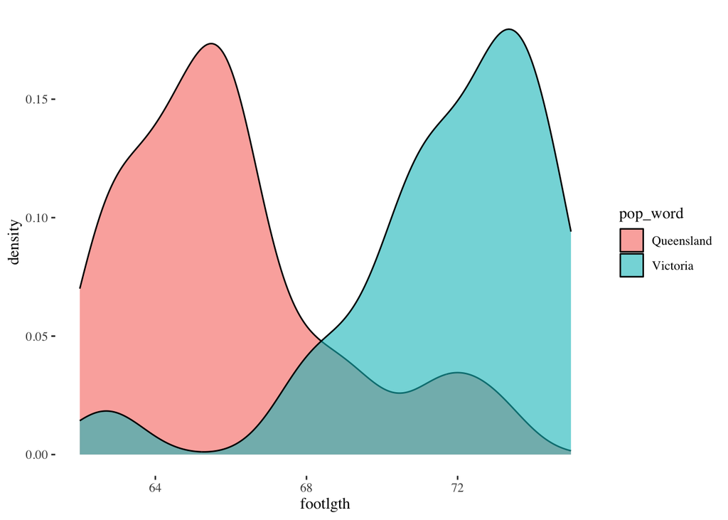

```r
#pass in a filtered dataset (filter for sex=="m")

possum |>
  mutate(pop_word = case_when(Pop=="Vic" ~ "Victoria",
                              Pop=="other" ~ "Queensland")) |>
  filter(sex=="m") |>
  ggplot(aes(x=footlgth, fill=pop_word)) +
  geom_density(alpha=0.6) +
  theme_tufte()
```

## Boxplots using `geom_boxplot`

**Tip**

Boxplots are good for displaying the spread, central tendency, and distribution of one numeric variable.

[figure not shown]

What information does a boxplot give us?

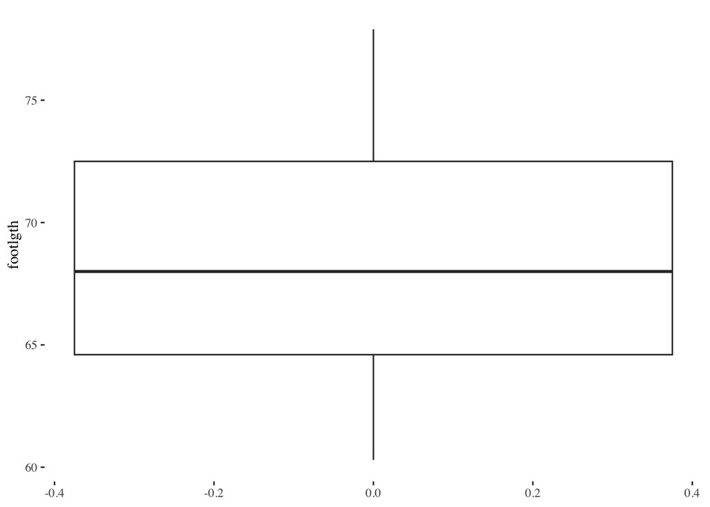

```r
# boxplot for footlgth
possum <- possum |>
  mutate(pop_word = case_when(Pop=="Vic" ~ "Victoria",
                              Pop=="other" ~ "Queensland"))

possum |>
  ggplot(aes(y=footlgth)) +
  geom_boxplot() +
  theme_tufte()
```

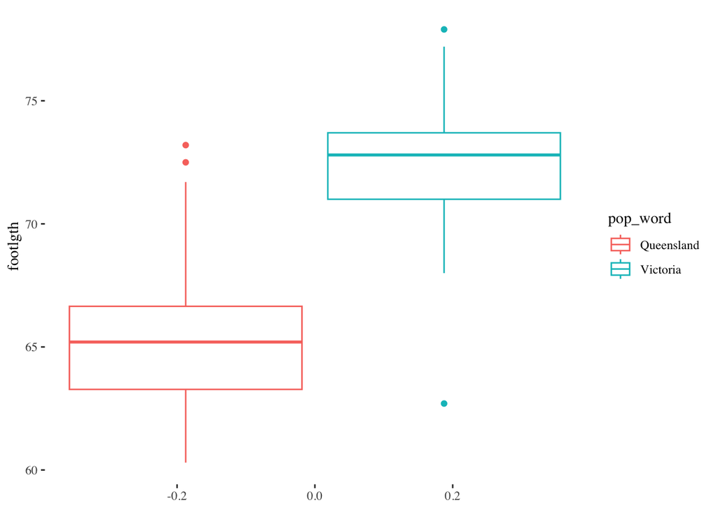

```r
#control color and fill inside geom_boxplot


possum |>
  ggplot(aes(y=footlgth, color=pop_word)) +
  geom_boxplot() +
  theme_tufte()
```

**Tip**

Side-by-side boxplots are good for displaying one categorical variable and one numeric variable. One advantage of boxplots over bar plots is that they are able to show a bit about the spread and distribution of the numeric variable!

A side-by-side boxplot to compare the foot lengths between the two populations of possums:

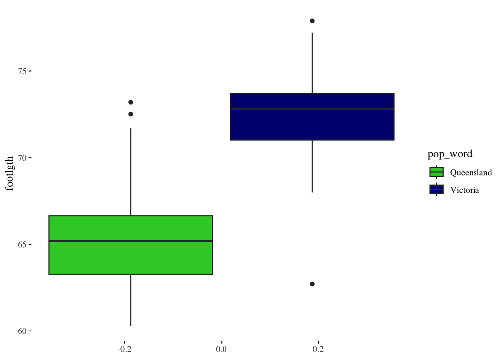

```r
# same color for both boxplots use footlgth
# group by population on the x-axis

# different color for both boxplots using color inside of aes()

possum |>
  ggplot(aes(y=footlgth, fill=pop_word)) +
  geom_boxplot() +
  scale_fill_manual(values=c("limegreen","navyblue")) +
  theme_tufte()
```

```r
# add theme


#alter the colors
```

A personal favorite of mine is to show a boxplot with something called a `jitter` which is done using `geom_jitter()`. I find that boxplots hide too much information about data distribution and I really like pairing the raw data with the boxplot that describes the statistical distribution.

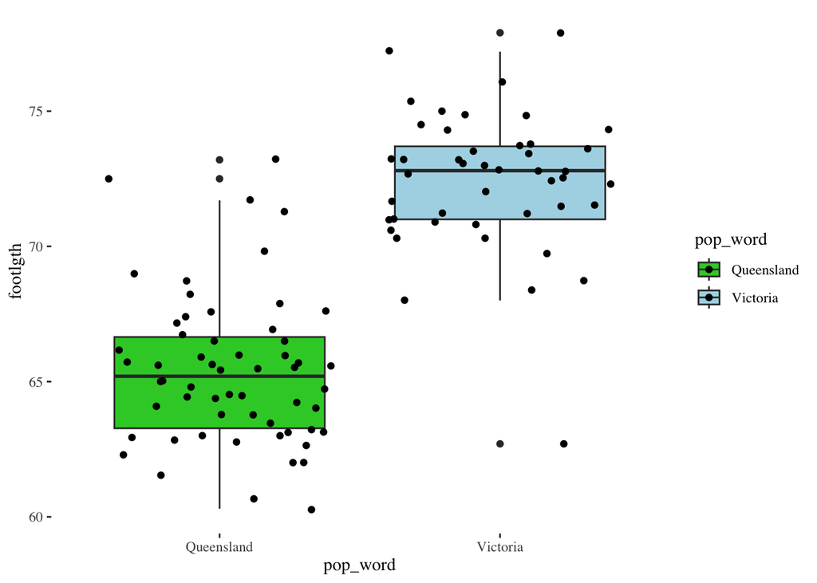

```r
# add a jitter (this is a personal favorite)
possum |>
  ggplot(aes(x=pop_word, y=footlgth, fill=pop_word)) +
  geom_boxplot() +
  geom_jitter() +
  scale_fill_manual(values=c("limegreen","lightblue")) +
  theme_tufte()
```

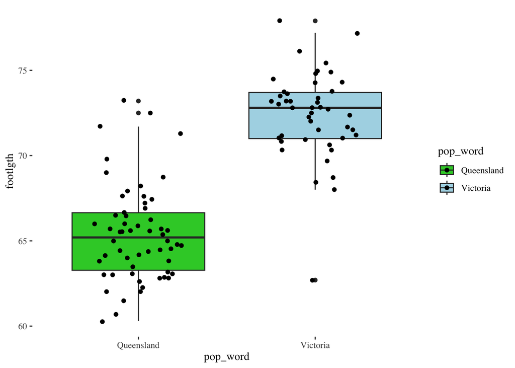

```r
# clean up

possum |>
  ggplot(aes(x=pop_word, y=footlgth, fill=pop_word)) +
  geom_boxplot() +
  geom_jitter(width=0.25) +
  scale_fill_manual(values=c("limegreen","lightblue")) +
  theme_tufte()
```

```r
# narrow the jitter using width inside of geom_jitter()
```

## Violin Plot

A violin plot is yet another plot type used to show data distribution.

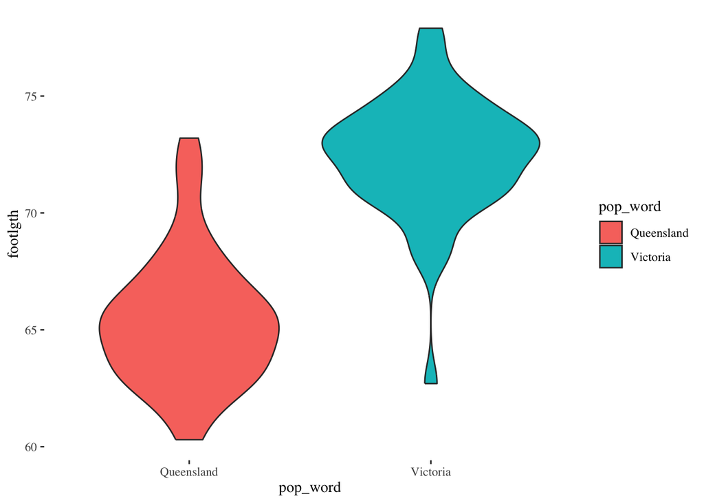

```r
# violin plot using geom_violin
possum |>
  ggplot(aes(x=pop_word, y=footlgth, fill=pop_word)) +
  geom_violin() +
  theme_tufte()
```

```r
# alter colors and theme


# add labels
```

**Tip**

Histograms, Boxplots, and Violin Plots are all different ways to visualize data distribution. Violin plots and Boxplots are especially good for comparing data distribution between groups.

## In class exercise

Choose one numeric variable from the possum dataset (not `footlgth`). Create two different distribution plots of that variable (choose from: histogram, density, boxplot, violin). Filter for only one of the populations (the `Pop` variable) and then compare across a different grouping variable (other than `Pop`).

- Change the theme
- Change the colors

Then write 3–4 sentences:

- What do you see? (Be specific.)
- What does each plot make clearer?
- What does each plot hide or distort?

*There is a spot on the Homework for you to copy your work from this section.*